# Merger recipients and their comparison organizations: matching methods and sample

November 21, 2026

This report describes how merger recipients are matched to comparison organizations for the difference-in-differences analysis, and what the matched sample looks like. Results are in the companion report (`model-report.html`). Both are built from `dev/analysis/did-recipients.R` and `dev/analysis/leadership-measures.R`.

# Treated units

**Mergers.** The treated units are recipients in two-party mergers (`merger2`): one organization dissolves and transfers most of its assets to one existing nonprofit, with evidence that the transfer was a merger (leadership continuity on Schedule N or Part VII, or the filer’s own merger language). Schedule N filings run from 2010 to 2024.

**Time.** Time 0 is the recipient’s tax year that contains the asset distribution date. All years are on the recipient’s own fiscal calendar; the donor’s years are on the donor’s calendar.

**Observation window.** A recipient must file a 990 or 990-EZ in every year from t-2 to t+2. The **baseline** is the mean of t-3 and t-2, with t-2 required. The baseline skips t-1 so that matching does not pick up a dip or surge in the year just before the merger.

**One unit per recipient-year.** A recipient that received two donors in the same year is one unit (17 cases). Recipients involved in another merger, as donor or recipient, within the window are dropped, so each unit has one clean event.

Sample construction

| Step | N |
| --- | --- |
| merger2 cases (2010-2024) | 9,984 |
| cases with recipient returns t-2..t+2 | 4,524 |
| recipient units with a t-2 baseline | 4,507 |
| units without other mergers in the window | 4,279 |
| units with >= 1 same-year control (recipient match) | 3,996 |
| units eligible for the combined match | 3,585 |
| units with >= 1 same-year control (combined match) | 3,382 |

# Comparison pool

The pool is every organization-year `YEAR` in the full 990 panel (2,975,950 organization-years, 506,514 organizations) that:

- filed in every year `YEAR-2` to `YEAR+2`, with a baseline in `YEAR-3` and `YEAR-2`;
- had no Schedule N involvement, as filer or named recipient, in `YEAR-3` to `YEAR+2`.

`YEAR` is the control’s pseudo-merger year. Dollar amounts are in constant 2024 dollars (CPI-U).

# Matching rules

For each recipient, a candidate control must:

| Rule | Value |
| --- | --- |
| Same NTEE group | first two characters (major group and first digit, e.g. `E2`) |
| Same calendar year | pseudo-merger year equals the recipient’s merger year |
| Baseline assets | within a factor of 2 (log difference ≤ log 2) |
| Baseline expenses | within a factor of 2 |
| Baseline operating margin | within 0.10 |

Candidates passing every rule are ranked by a standardized distance: the root mean square of the differences in log assets, log expenses, and margin, each divided by its standard deviation in the pool. The **5 nearest** become controls. A recipient with fewer candidates keeps all it has. In the models each control is weighted 1/k within its set, so every recipient counts once.

**Why the same calendar year?** Controls are allowed only from the recipient’s own year. The matched-set × event-time fixed effects then absorb year shocks (the 2020 revenue shock, inflation) exactly. Allowing other years would require separate calendar-year effects.

## Two matches

- **Recipient match.** Controls are matched on the recipient’s own baseline. This is the natural comparison for “how did the recipient do?”
- **Combined match.** Controls are re-matched with the same rules on the combined baseline of recipient plus donor: summed assets and expenses, and a revenue-weighted margin. This is the natural comparison for “how did the merged organization do compared with the two separately?” It needs the donor’s baseline, so it covers fewer recipients.

# Match coverage

Coverage and closeness of the match by recipient size (baseline real assets)

| Recipient assets | Recipients | Matched (recipient) | Share matched | Median gap, log assets | Eligible (combined) | Matched (combined) | Median gap, combined |
| --- | --- | --- | --- | --- | --- | --- | --- |
| <$10m | 2,302 | 2,189 | 95% | 0.135 | 1,895 | 1,844 | 0.134 |
| $10-100m | 1,318 | 1,235 | 94% | 0.146 | 1,118 | 1,038 | 0.149 |
| >=$100m | 659 | 572 | 87% | 0.126 | 572 | 500 | 0.126 |

# Balance

Standardized mean differences (SMD) compare recipients with their weighted controls, and with the whole pool in the same year and NTEE groups. Dollar measures and employees are on the log(1 + x) scale. An SMD under 0.1 is conventionally considered balanced.

Covariate balance at baseline (mean of t-3 and t-2)

| Match | Variable | Scale | Treated | Matched controls | Pool (same year, NTEE2) | SMD matched | SMD pool |
| --- | --- | --- | --- | --- | --- | --- | --- |
| recipient match | REAL_ASSETS | log(1 + x) | 15.73 | 15.72 | 13.08 | 0.006 | 1.013 |
| recipient match | REAL_EXPENSES | log(1 + x) | 15.31 | 15.29 | 12.77 | 0.008 | 1.081 |
| recipient match | REAL_REVENUE | log(1 + x) | 15.42 | 15.40 | 12.85 | 0.007 | 1.088 |
| recipient match | MARGIN | level | 0.06 | 0.06 | 0.04 | 0.000 | 0.076 |
| recipient match | EQUITY_RATIO | level | 0.69 | 0.68 | 0.77 | 0.006 | -0.235 |
| recipient match | MONTHS_CASH | level | 8.39 | 8.23 | 14.36 | 0.007 | -0.292 |
| recipient match | EMPLOYEES | log(1 + x) | 3.66 | 3.52 | 1.89 | 0.062 | 0.809 |
| combined match | REAL_ASSETS | log(1 + x) | 16.11 | 16.10 | 13.10 | 0.007 | 1.200 |
| combined match | REAL_EXPENSES | log(1 + x) | 15.67 | 15.65 | 12.79 | 0.010 | 1.296 |
| combined match | REAL_REVENUE | log(1 + x) | 15.74 | 15.73 | 12.87 | 0.003 | 1.268 |
| combined match | MARGIN | level | 0.05 | 0.05 | 0.04 | -0.003 | 0.044 |
| combined match | EQUITY_RATIO | level | 0.68 | 0.67 | 0.77 | 0.030 | -0.239 |
| combined match | MONTHS_CASH | level | 8.44 | 7.13 | 14.31 | 0.063 | -0.284 |
| combined match | EMPLOYEES | log(1 + x) | 3.92 | 3.68 | 1.90 | 0.112 | 0.936 |

Matching removes almost all of the size difference between recipients and other organizations. Before matching, recipients are about one standard deviation larger than their sector peers. Equity ratio and months of cash were not matched on, but they balance well too. Employees are slightly less balanced (SMD 0.11 in the combined match), because the donor’s 990-EZ filers report no employee count.

# Sample traits

## Size

Baseline size (mean of t-3 and t-2, 2024 dollars)

| Measure | p25 | Median | p75 |
| --- | --- | --- | --- |
| Recipient revenue | $1.0m | $5.2m | $24.0m |
| Recipient assets | $1.2m | $7.3m | $36.4m |
| Recipient employees (full 990) | 6 | 38 | 250 |
| Donor revenue | $111k | $417k | $1.7m |
| Donor assets | $165k | $737k | $3.5m |
| Combined revenue | $1.6m | $6.8m | $28.7m |
| Combined assets | $2.0m | $10.1m | $46.4m |
| Transfer / recipient assets (t-2) | 0.7% | 5.9% | 29.6% |

The typical merger is a much larger organization absorbing a much smaller one. The median transfer is a few percent of the recipient’s assets.

### Donor size relative to recipient

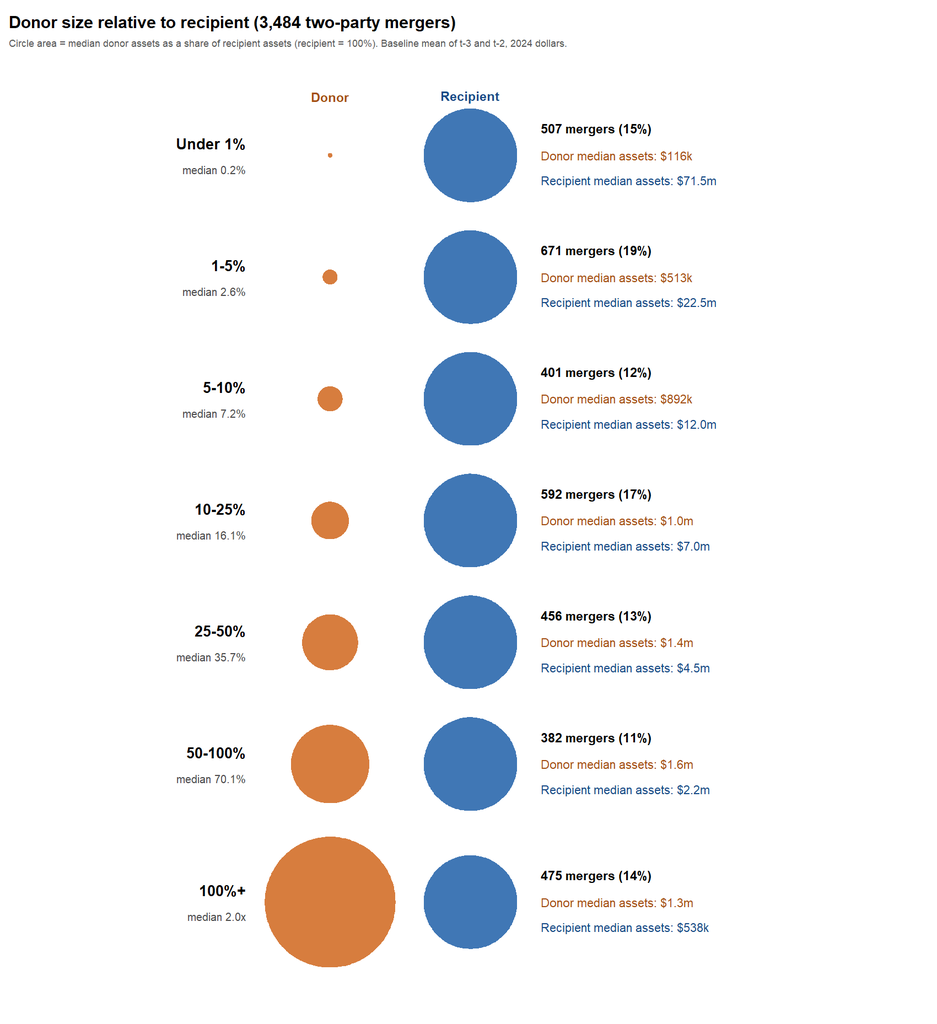

Each row groups mergers by the donor’s baseline assets as a share of the recipient’s. The recipient circle is fixed at 100%. The donor circle’s **area** is the group’s median ratio. The groups are drawn at break points that put 11–19% of mergers in each row.

Donor size relative to recipient (mergers with a donor baseline; 2024 dollars)

| Donor assets as % of recipient | Mergers | Share | Median ratio | Donor median assets | Recipient median assets |
| --- | --- | --- | --- | --- | --- |
| Under 1% | 507 | 15% | 0.2% | $116k | $71.5m |
| 1-5% | 671 | 19% | 2.6% | $513k | $22.5m |
| 5-10% | 401 | 12% | 7.2% | $892k | $12.0m |
| 10-25% | 592 | 17% | 16.1% | $1.0m | $7.0m |
| 25-50% | 456 | 13% | 35.7% | $1.4m | $4.5m |
| 50-100% | 382 | 11% | 70.1% | $1.6m | $2.2m |
| 100%+ | 475 | 14% | 2.0x | $1.3m | $538k |

Donor size varies far less than recipient size. Median donors range from about $0.1m to $1.6m across the groups, while median recipients range from $71.5m down to $0.5m. So the ratio mostly reflects how large the recipient is:

- At the top, small donors fold into large systems.
- At the bottom are near-equals, and mergers where the donor is larger than the recipient (14%, median 2×).

Transfer size

| Transfer size (FMV / recipient assets) | N | Share |
| --- | --- | --- |
| <1% | 1,068 | 27% |
| 1-10% | 1,147 | 29% |
| 10-50% | 919 | 23% |
| >=50% | 669 | 17% |
| unknown | 193 | 5% |

## Year, sector, and affiliation

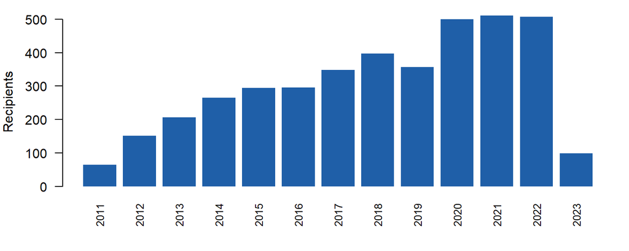

Recipients by NTEE major group

| Sector | N | Share |
| --- | --- | --- |
| Health | 672 | 16.8% |
| Human services | 604 | 15.1% |
| Education | 469 | 11.7% |
| Community improvement | 322 | 8.1% |
| Employment | 226 | 5.7% |
| Arts | 201 | 5.0% |
| Philanthropy | 184 | 4.6% |
| Housing | 160 | 4.0% |
| Recreation & sports | 152 | 3.8% |
| Public benefit | 149 | 3.7% |
| Mental health | 148 | 3.7% |
| Mutual benefit | 123 | 3.1% |
| Youth development | 98 | 2.5% |
| Religion | 76 | 1.9% |
| Disease | 70 | 1.8% |
| Environment | 54 | 1.4% |
| International | 53 | 1.3% |
| Animals | 50 | 1.3% |
| Crime & legal | 38 | 1.0% |
| Food & agriculture | 35 | 0.9% |
| Public safety | 31 | 0.8% |
| Medical research | 23 | 0.6% |
| Unknown | 20 | 0.5% |
| Civil rights | 17 | 0.4% |
| Science | 16 | 0.4% |
| Social science | 5 | 0.1% |

Affiliated donor-recipient pairs (Schedule R link, supporting organization, or shared group exemption)

| Affiliated | N | Share |
| --- | --- | --- |
| TRUE | 1,799 | 45% |
| FALSE | 2,197 | 55% |

## Leadership and board outcomes

These are measured from Part VII rosters (`dev/analysis/leadership-measures.R`) and are available for single-donor units with donor, recipient-before, and recipient-after rosters.

**CEO.** The CEO is the person with a CEO, executive director, president & CEO, administrator, or superintendent title. If there is none, it is the highest-paid officer or key employee.

- The donor’s CEO comes from its last roster at or before t0.
- The recipient’s CEO comes from its last roster before t0.
- “Remains” means the person is on the recipient’s roster at t+1 or t+2, in any role.

| CEO category | Meaning |
| --- | --- |
| `recipient_ceo_only` | Recipient’s CEO remains; donor’s CEO does not join |
| `both_ceos` | Both remain at the recipient |
| `donor_ceo_only` | Donor’s CEO joins; recipient’s CEO leaves |
| `neither` | Both gone |
| `shared_ceo` | The same person already led both, or the donor’s CEO was on the recipient’s roster before the merger |

**Board.** The governing roster counts trustees and officers, plus 990-EZ listings. It excludes staff who are only key employees or highly compensated, and former officers.

- *Retention* is the share of the recipient’s t-1 roster still present at t+1.
- *Donor joiners* are donor members who appear at t+1 and were not already on the recipient’s roster.

| Board category | Meaning |
| --- | --- |
| `intact_donor_dissolves` | Recipient keeps at least half its board; no donor members join |
| `combine_minor` | Recipient keeps at least half; donor joiners hold under 20% of seats |
| `combine_major` | Recipient keeps at least half; donor joiners hold 20% or more |
| `recipient_turnover` | Recipient keeps under half its board |

| CEO | N | Share |
| --- | --- | --- |
| (not identified) | 2,430 | 61% |
| shared_ceo | 672 | 17% |
| recipient_ceo_only | 597 | 15% |
| neither | 120 | 3% |
| both_ceos | 111 | 3% |
| donor_ceo_only | 66 | 2% |

| Board | N | Share |
| --- | --- | --- |
| intact_donor_dissolves | 1,897 | 47% |
| combine_minor | 937 | 23% |
| recipient_turnover | 764 | 19% |
| combine_major | 309 | 8% |
| (not observed) | 89 | 2% |

|  | intact_donor_dissolves | combine_minor | combine_major | recipient_turnover |
| --- | --- | --- | --- | --- |
| recipient_ceo_only | 285 | 196 | 42 | 73 |
| both_ceos | 15 | 52 | 21 | 23 |
| donor_ceo_only | 2 | 20 | 10 | 34 |
| neither | 35 | 31 | 9 | 45 |
| shared_ceo | 315 | 173 | 74 | 110 |

A CEO can be identified for both organizations in 39% of recipients. The rest are mostly small, volunteer-run donors with no paid staff and no CEO title. Board outcomes are observed for almost all of them. The most common pattern is the recipient’s board staying intact while the donor’s board dissolves. About a third of mergers bring donor board members onto the recipient’s board.

**Caution.** These categories are measured *after* the merger. They describe how mergers unfold rather than being assigned beforehand, so differences in outcomes across them are associations, not causal effects of governance choices.